# PS4

Victor Cheng

2023-10-23

```r
setwd("/Users/victor_cheng/Desktop/Econ487")
```

```r
suppressPackageStartupMessages({
  library(ggplot2)
  library(tidyverse)
  library(broom)
  library(knitr)
  library(glmnet)
  library(rpart)
  library(maptree)
  library(dplyr)
})

options(dplyr.summarise.inform = FALSE)
```

```r
oj <- read.csv("oj.csv")
```

```r
#install.packages("rpart.plot")
```

```r
#install.packages("maptree")
```

```r
#install.packages("dplyr")
```

```r
oj_reg_demo <- oj %>%
  mutate(id_val = row_number(),
         log_price = log(price))

demo_cols <- oj %>%
  select(AGE60:HVAL150) %>%
  colnames()
```

```r
oj_cv <- oj %>%
  mutate(log_price = log(price)) %>%
  arrange(week) %>%
  group_by(store, brand) %>%
  mutate(lag_price = ifelse(lag(week) + 1 == week, lag(log_price), NA)) %>%
  ungroup() %>%
  filter(!is.na(lag_price)) %>%
  mutate(dataset_id = sample(
           rep(c(1:5), ceiling(n()/5)),
           size = n(),
           replace = FALSE
         ))

head(oj_cv, 10) %>%
  kable()
```

| store | brand | week | logmove | feat | price | AGE60 | EDUC | ETHNIC | INCOME | HHLARGE | WORKWOM | HVAL150 | SSTRDIST | SSTRVOL | CPDIST5 | CPWVOL5 | log_price | lag_price | dataset_id |
| --- | --- | --- | --- | --- | --- | --- | --- | --- | --- | --- | --- | --- | --- | --- | --- | --- | --- | --- | --- |
| 8 | tropicana | 41 | 8.895081 | 0 | 3.19 | 0.2523940 | 0.0951733 | 0.0352433 | 10.59701 | 0.1317497 | 0.2830747 | 0.0542272 | 2.6363328 | 1.5000000 | 2.905384 | 0.6410159 | 1.1600209 | 1.1600209 | 4 |
| 8 | minute.maid | 41 | 10.858383 | 1 | 1.99 | 0.2523940 | 0.0951733 | 0.0352433 | 10.59701 | 0.1317497 | 0.2830747 | 0.0542272 | 2.6363328 | 1.5000000 | 2.905384 | 0.6410159 | 0.6881346 | 0.9631743 | 5 |
| 8 | dominicks | 41 | 8.764053 | 0 | 2.29 | 0.2523940 | 0.0951733 | 0.0352433 | 10.59701 | 0.1317497 | 0.2830747 | 0.0542272 | 2.6363328 | 1.5000000 | 2.905384 | 0.6410159 | 0.8285518 | 0.4637340 | 4 |
| 9 | tropicana | 41 | 9.078864 | 0 | 3.19 | 0.2691190 | 0.2221723 | 0.0326188 | 10.78715 | 0.0968305 | 0.3589945 | 0.5057471 | 1.1032787 | 0.6666667 | 1.820474 | 0.4412683 | 1.1600209 | 1.1600209 | 3 |
| 9 | minute.maid | 41 | 11.172799 | 1 | 1.99 | 0.2691190 | 0.2221723 | 0.0326188 | 10.78715 | 0.0968305 | 0.3589945 | 0.5057471 | 1.1032787 | 0.6666667 | 1.820474 | 0.4412683 | 0.6881346 | 0.9631743 | 1 |
| 9 | dominicks | 41 | 7.049255 | 0 | 2.29 | 0.2691190 | 0.2221723 | 0.0326188 | 10.78715 | 0.0968305 | 0.3589945 | 0.5057471 | 1.1032787 | 0.6666667 | 1.820474 | 0.4412683 | 0.8285518 | 0.4637340 | 1 |
| 14 | tropicana | 41 | 8.783856 | 0 | 3.87 | 0.2139493 | 0.3482930 | 0.0341787 | 11.04393 | 0.1078943 | 0.3623057 | 0.7507699 | 3.3209476 | 0.7500000 | 2.359891 | 0.7318100 | 1.3532545 | 1.3532545 | 3 |
| 14 | minute.maid | 41 | 10.590214 | 1 | 1.99 | 0.2139493 | 0.3482930 | 0.0341787 | 11.04393 | 0.1078943 | 0.3623057 | 0.7507699 | 3.3209476 | 0.7500000 | 2.359891 | 0.7318100 | 0.6881346 | 1.1537316 | 5 |
| 14 | dominicks | 41 | 7.249925 | 0 | 2.69 | 0.2139493 | 0.3482930 | 0.0341787 | 11.04393 | 0.1078943 | 0.3623057 | 0.7507699 | 3.3209476 | 0.7500000 | 2.359891 | 0.7318100 | 0.9895412 | 0.4637340 | 2 |
| 21 | tropicana | 41 | 7.872455 | 0 | 3.19 | 0.0668965 | 0.1775034 | 0.1050388 | 10.71619 | 0.1641791 | 0.4060709 | 0.1234857 | 0.2675247 | 1.0500000 | 1.953944 | 0.6020732 | 1.1600209 | 1.1600209 | 4 |

```r
#install.packages("glmnet")
```

```r
model <- logmove ~ log_price*feat*brand + log_price*WORKWOM +INCOME * WORKWOM + lag_price + SSTRVOL * CPWVOL5 + log_price * lag_price + feat * INCOME +  AGE60 + EDUC + ETHNIC + HHLARGE + HVAL150
```

```r
x <- model.matrix(model,oj_cv)
y <- as.numeric(as.matrix(oj_cv[ ,4]))
```

```r
set.seed(720)
lasso_v1_cv<- cv.glmnet(x, y, alpha=1)
lasso_v1 <- glmnet(x, y, alpha=1)

lasso_v1_cv
```

```
##
## Call:  cv.glmnet(x = x, y = y, alpha = 1)
##
## Measure: Mean-Squared Error
##
##        Lambda Index Measure       SE Nonzero
## min 0.0003888    79  0.4213 0.004092      24
## 1se 0.0022769    60  0.4248 0.004221      22
```

```r
lasso_v1
```

```
##
## Call:  glmnet(x = x, y = y, alpha = 1)
##
##    Df  %Dev  Lambda
## 1   0  0.00 0.55100
## 2   1  4.95 0.50210
## 3   1  9.07 0.45750
## 4   2 13.24 0.41680
## 5   2 17.65 0.37980
## 6   2 21.32 0.34610
## 7   2 24.36 0.31530
## 8   2 26.89 0.28730
## 9   3 29.02 0.26180
## 10  3 30.81 0.23850
## 11  3 32.29 0.21730
```

[output cut: 68 more lines]

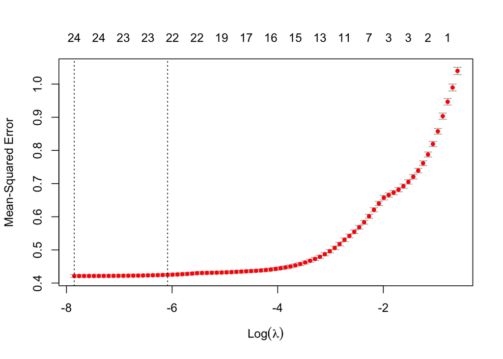

```r
plot(lasso_v1_cv)
```

```r
coef(lasso_v1_cv, s=lasso_v1_cv$lambda.min)
```

```
## 28 x 1 sparse Matrix of class "dgCMatrix"
##                                            s1
## (Intercept)                      1.322054e+01
## (Intercept)                      .
## log_price                       -4.365931e+00
## feat                             8.636226e-01
## brandminute.maid                 .
## brandtropicana                   5.510636e-01
## WORKWOM                         -4.127497e+00
## INCOME                          -1.684482e-01
## lag_price                        7.932650e-01
## SSTRVOL                         -1.022453e-03
## CPWVOL5                         -1.058781e-01
## AGE60                            1.477800e+00
## EDUC                             8.136095e-01
## ETHNIC                           4.251147e-01
## HHLARGE                         -1.453265e+00
## HVAL150                          2.237286e-01
## log_price:feat                  -4.859310e-03
## log_price:brandminute.maid       8.185644e-01
## log_price:brandtropicana         8.790564e-01
## feat:brandminute.maid            1.067103e+00
## feat:brandtropicana              3.893849e-01
## log_price:WORKWOM                4.034413e+00
## WORKWOM:INCOME                   .
## SSTRVOL:CPWVOL5                 -1.914098e-01
## log_price:lag_price             -4.096593e-01
## feat:INCOME                     -4.056770e-06
## log_price:feat:brandminute.maid -1.257278e+00
## log_price:feat:brandtropicana   -8.685359e-01
```

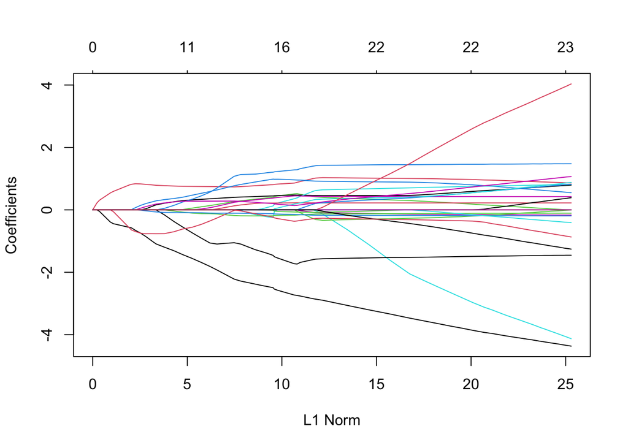

```r
plot(lasso_v1)
```

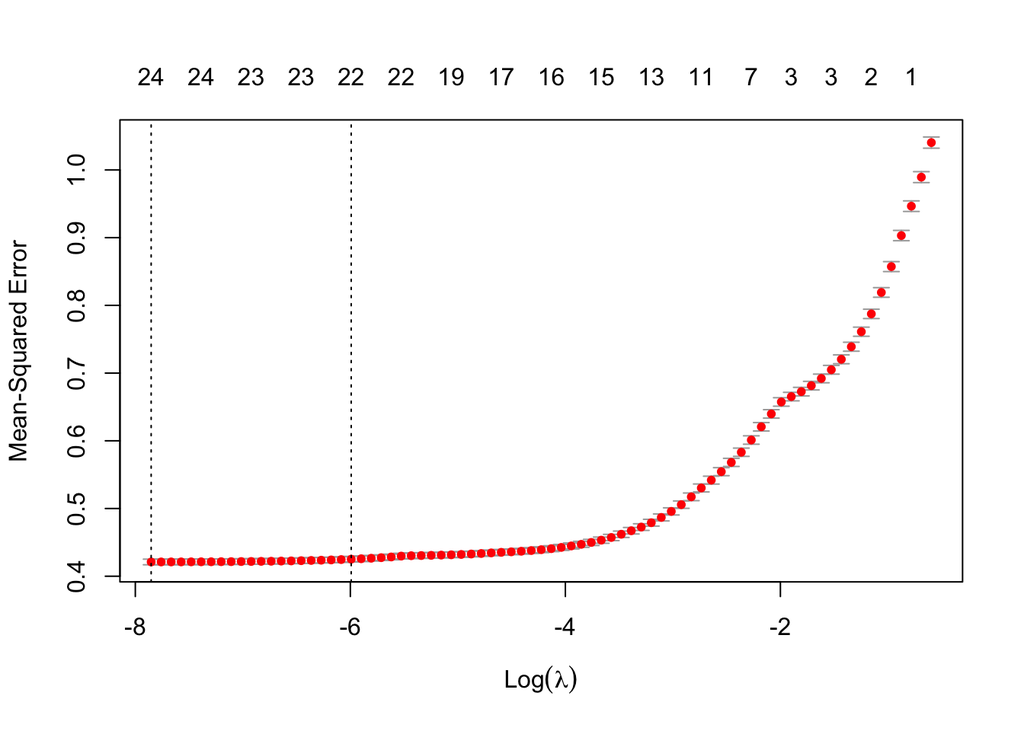

```r
cvfit <- cv.glmnet(x, y, alpha=1)
plot(cvfit)
```

```r
cvfit$lambda.min
```

```
## [1] 0.0003887507
```

```r
log(cvfit$lambda.min)
```

```
## [1] -7.852572
```

```r
coef(cvfit, s = "lambda.min")
```

```
## 28 x 1 sparse Matrix of class "dgCMatrix"
##                                            s1
## (Intercept)                      1.322054e+01
## (Intercept)                      .
## log_price                       -4.365931e+00
## feat                             8.636226e-01
## brandminute.maid                 .
## brandtropicana                   5.510636e-01
## WORKWOM                         -4.127497e+00
## INCOME                          -1.684482e-01
## lag_price                        7.932650e-01
## SSTRVOL                         -1.022453e-03
## CPWVOL5                         -1.058781e-01
## AGE60                            1.477800e+00
## EDUC                             8.136095e-01
## ETHNIC                           4.251147e-01
## HHLARGE                         -1.453265e+00
## HVAL150                          2.237286e-01
## log_price:feat                  -4.859310e-03
## log_price:brandminute.maid       8.185644e-01
## log_price:brandtropicana         8.790564e-01
## feat:brandminute.maid            1.067103e+00
## feat:brandtropicana              3.893849e-01
## log_price:WORKWOM                4.034413e+00
## WORKWOM:INCOME                   .
## SSTRVOL:CPWVOL5                 -1.914098e-01
## log_price:lag_price             -4.096593e-01
## feat:INCOME                     -4.056770e-06
## log_price:feat:brandminute.maid -1.257278e+00
## log_price:feat:brandtropicana   -8.685359e-01
```

```r
num_folds <- 5

cv_results <- numeric(num_folds)

set.seed(487)
indices <- sample(1:num_folds, nrow(oj_cv), replace = TRUE)

for (fold in 1:num_folds) {
  train_df <- oj_cv[indices != fold, ]
  test_df <- oj_cv[indices == fold, ]

  x_train <- model.matrix(model, data = train_df)
  y_train <- train_df$logmove

  lasso_model <- cv.glmnet(x_train, y_train, alpha = 1)

  x_test <- model.matrix(model, data = test_df)
  y_pred <- predict(lasso_model, s = "lambda.min", newx = x_test)

  test_mse <- mean((test_df$logmove - y_pred)^2)
  cv_results[fold] <- test_mse
}

print(cv_results)
```

```
## [1] 0.4142857 0.4224506 0.4106087 0.4313714 0.4258370
```

```r
ave_mse=(0.4142857+0.4224506+0.4106087+0.4313714+0.4258370)/5
ave_mse
```

```
## [1] 0.4209107
```

0.4209107, which is less than 0.462 from the previous problem set.

5. LASSO can increase the prediction accuracy by adding a penalty equivalent to the absolute value of the magnitude of coefficients. If I use my own intuition as an economist, I might just decided what variables needed to be added based on economic theories or just common sense, and that might be wrong.
6. In this process, I used my intuition as an economist when I defined what’s in the X matrix. I decided which variables might have a plausible relationship with my outcome variable and included them as predictors in my model.

```r
reg <- lm(logmove ~ log_price*feat*brand + log_price*WORKWOM + lag_price + SSTRVOL * CPWVOL5 + log_price * lag_price + feat * INCOME +  AGE60 + EDUC + ETHNIC + HHLARGE + HVAL150, data=oj_cv)
summary(reg)
```

```
##
## Call:
## lm(formula = logmove ~ log_price * feat * brand + log_price *
##     WORKWOM + lag_price + SSTRVOL * CPWVOL5 + log_price * lag_price +
##     feat * INCOME + AGE60 + EDUC + ETHNIC + HHLARGE + HVAL150,
##     data = oj_cv)
##
## Residuals:
##     Min      1Q  Median      3Q     Max
## -5.2384 -0.3812  0.0010  0.3718  2.8809
##
## Coefficients:
##                                  Estimate Std. Error t value Pr(>|t|)
## (Intercept)                     12.912697   0.345315  37.394  < 2e-16 ***
## log_price                       -4.536398   0.103093 -44.003  < 2e-16 ***
## feat                             2.841358   0.348037   8.164 3.38e-16 ***
## brandminute.maid                -0.103792   0.048605  -2.135 0.032734 *
## brandtropicana                   0.410237   0.060664   6.762 1.38e-11 ***
## WORKWOM                         -4.484185   0.248548 -18.042  < 2e-16 ***
## lag_price                        0.876562   0.057743  15.180  < 2e-16 ***
## SSTRVOL                         -0.002785   0.021498  -0.130 0.896909
## CPWVOL5                         -0.105781   0.062185  -1.701 0.088939 .
## INCOME                          -0.127559   0.033668  -3.789 0.000152 ***
## AGE60                            1.473799   0.124637  11.825  < 2e-16 ***
## EDUC                             0.830165   0.102139   8.128 4.55e-16 ***
## ETHNIC                           0.425114   0.037457  11.349  < 2e-16 ***
## HHLARGE                         -1.452077   0.228908  -6.344 2.28e-10 ***
## HVAL150                          0.223052   0.041090   5.428 5.73e-08 ***
## log_price:feat                   0.110877   0.073631   1.506 0.132120
## log_price:brandminute.maid       0.966906   0.064148  15.073  < 2e-16 ***
## log_price:brandtropicana         1.058052   0.070977  14.907  < 2e-16 ***
## feat:brandminute.maid            1.229721   0.078409  15.684  < 2e-16 ***
## feat:brandtropicana              0.606499   0.095330   6.362 2.02e-10 ***
## log_price:WORKWOM                4.461576   0.256370  17.403  < 2e-16 ***
## SSTRVOL:CPWVOL5                 -0.191001   0.040696  -4.693 2.70e-06 ***
## log_price:lag_price             -0.514384   0.065425  -7.862 3.91e-15 ***
## feat:INCOME                     -0.192342   0.032492  -5.920 3.26e-09 ***
## log_price:feat:brandminute.maid -1.505149   0.117650 -12.793  < 2e-16 ***
## log_price:feat:brandtropicana   -1.149340   0.119452  -9.622  < 2e-16 ***
## ---
## Signif. codes:  0 '***' 0.001 '**' 0.01 '*' 0.05 '.' 0.1 ' ' 1
##
## Residual standard error: 0.648 on 27982 degrees of freedom
## Multiple R-squared:  0.5969, Adjusted R-squared:  0.5965
## F-statistic:  1657 on 25 and 27982 DF,  p-value: < 2.2e-16
```

So for Dominicks, the predicted elasticity is -4.536398-0.514384*1(lag_price)=-5.050782

2. For Tropicana the elasticity is -4.536398+ 1.058052=-3.478346
3. For Tropicana when its featured–4.536398-1.149340=-5.685738.

```r
confint(reg, 'log_price:brandtropicana', level=0.95)
```

```
##                             2.5 %   97.5 %
## log_price:brandtropicana 0.918933 1.197171
```

So the confidence interval for tropicana is [0.918933,1.197171]

Dominicks has the most elastic demand.

1. Products with more elastic demand should have a lower markup over costs because a lower price would lead to a larger increase in quantity demanded for these products, which could lead to higher total revenue.

```r
wide_data <- oj_reg_demo %>%
  select(store, week, brand, log_price) %>%
  pivot_wider(
    id_cols = c(store,week),
    names_from = brand,
    values_from=log_price
  )

head(wide_data, 10) %>%
  kable()
```

| store | week | tropicana | minute.maid | dominicks |
| --- | --- | --- | --- | --- |
| 2 | 40 | 1.353255 | 1.1537316 | 0.4637340 |
| 2 | 46 | 1.353255 | 1.1537316 | 0.9895412 |
| 2 | 47 | 1.353255 | 0.8712934 | 0.7371641 |
| 2 | 48 | 1.353255 | 1.1537316 | 0.7371641 |
| 2 | 50 | 1.353255 | 1.1537316 | 0.7371641 |
| 2 | 51 | 1.353255 | 1.1537316 | 0.6365768 |
| 2 | 52 | 1.190888 | 1.1537316 | 0.6365768 |
| 2 | 53 | 1.190888 | 0.7839015 | 0.6365768 |
| 2 | 54 | 1.190888 | 1.1537316 | 0.5822156 |
| 2 | 57 | 1.190888 | 0.6881346 | 0.9895412 |

```r
cross_price_data <- oj_reg_demo %>%
  select(store, week, logmove, brand) %>%
  left_join(wide_data,
            by = c('store', 'week'))

reg_cross_price <- lm(logmove ~ brand + brand:tropicana + brand:minute.maid + brand:dominicks,
                      data = cross_price_data)

tidy(reg_cross_price) %>%
  kable()
```

| term | estimate | std.error | statistic | p.value |
| --- | --- | --- | --- | --- |
| (Intercept) | 10.0843815 | 0.0473070 | 213.169098 | 0.0000000 |
| brandminute.maid | 0.4960975 | 0.0669021 | 7.415271 | 0.0000000 |
| brandtropicana | 1.4964182 | 0.0669021 | 22.367269 | 0.0000000 |
| branddominicks:tropicana | 0.0269841 | 0.0394791 | 0.683503 | 0.4942945 |
| brandminute.maid:tropicana | 1.1768804 | 0.0394791 | 29.810211 | 0.0000000 |
| brandtropicana:tropicana | -2.8660924 | 0.0394791 | -72.597708 | 0.0000000 |
| branddominicks:minute.maid | 1.1743612 | 0.0445384 | 26.367409 | 0.0000000 |
| brandminute.maid:minute.maid | -3.8662154 | 0.0445384 | -86.806409 | 0.0000000 |
| brandtropicana:minute.maid | 0.4506940 | 0.0445384 | 10.119231 | 0.0000000 |
| branddominicks:dominicks | -3.5410460 | 0.0353685 | -100.118583 | 0.0000000 |
| brandminute.maid:dominicks | 0.9035890 | 0.0353685 | 25.547833 | 0.0000000 |
| brandtropicana:dominicks | 0.2648684 | 0.0353685 | 7.488817 | 0.0000000 |

```r
cross_price_matrix <- tidy(reg_cross_price) %>%
  select(term, estimate) %>%
  filter(str_detect(term, '\\:')) %>%
  mutate(num = str_extract(term, '(?<=brand).*(?=:)'),
         den = str_extract(term, '(?<=:).*(?=$)')) %>%
  select(num, den, estimate) %>%
  arrange(num, den) %>%
  pivot_wider(id_cols = num, names_from = den, values_from = estimate)

kable(cross_price_matrix)
```

| num | dominicks | minute.maid | tropicana |
| --- | --- | --- | --- |
| dominicks | -3.5410460 | 1.174361 | 0.0269841 |
| minute.maid | 0.9035890 | -3.866215 | 1.1768804 |
| tropicana | 0.2648684 | 0.450694 | -2.8660924 |

1. Dominicks:-3.5410460

Miniute.maid:-3.866215

Tropicana:-2.8660924

Dominicks with Minute.maid:1.174361

Dominicks with Tropicana:0.0269841

Minute.maid with Tropicana:1.1768804

```r
cross_price_data_featured <- oj_reg_demo %>%
  select(store, week, logmove, brand,feat) %>%
  left_join(wide_data,
            by = c('store', 'week'))

reg_cross_price_feat <- lm(logmove ~ brand + brand:tropicana:feat + brand:minute.maid:feat + brand:dominicks:feat,
                      data = cross_price_data_featured)

tidy(reg_cross_price_feat) %>%
  kable()
```

| term | estimate | std.error | statistic | p.value |
| --- | --- | --- | --- | --- |
| (Intercept) | 8.8564443 | 0.0094957 | 932.681783 | 0.0000000 |
| brandminute.maid | -0.0383225 | 0.0135886 | -2.820197 | 0.0048027 |
| brandtropicana | 0.0948172 | 0.0130732 | 7.252808 | 0.0000000 |
| branddominicks:tropicana:feat | 0.8325077 | 0.0693942 | 11.996782 | 0.0000000 |
| brandminute.maid:tropicana:feat | 2.5441598 | 0.0626952 | 40.579831 | 0.0000000 |
| brandtropicana:tropicana:feat | -2.5722191 | 0.1095285 | -23.484465 | 0.0000000 |
| branddominicks:feat:minute.maid | 2.1658080 | 0.0927209 | 23.358362 | 0.0000000 |
| brandminute.maid:feat:minute.maid | -2.5817520 | 0.0830286 | -31.094715 | 0.0000000 |
| brandtropicana:feat:minute.maid | 2.8089156 | 0.1281093 | 21.925930 | 0.0000000 |
| branddominicks:feat:dominicks | -3.2364560 | 0.0723342 | -44.743125 | 0.0000000 |
| brandminute.maid:feat:dominicks | 0.7381813 | 0.0752793 | 9.805901 | 0.0000000 |
| brandtropicana:feat:dominicks | 1.7339956 | 0.1231088 | 14.085064 | 0.0000000 |

```r
cross_price_feat_matrix <- tidy(reg_cross_price_feat) %>%
  select(term, estimate) %>%
  filter(str_detect(term, '\\:')) %>%
  mutate(num = str_extract(term, '(?<=brand).*(?=:)'),
         den = str_extract(term, '(?<=:).*(?=$)')) %>%
  select(num, den, estimate) %>%
  arrange(num, den) %>%
  pivot_wider(id_cols = num, names_from = den, values_from = estimate)

kable(cross_price_feat_matrix)
```

| num | feat:dominicks | feat:minute.maid | tropicana:feat |
| --- | --- | --- | --- |
| dominicks:feat | -3.2364560 | 2.165808 | NA |
| dominicks:tropicana | NA | NA | 0.8325077 |
| minute.maid:feat | 0.7381813 | -2.581752 | NA |
| minute.maid:tropicana | NA | NA | 2.5441598 |
| tropicana:feat | 1.7339956 | 2.808916 | NA |
| tropicana:tropicana | NA | NA | -2.5722191 |

2. For Dominicks when it is featured: -3.2364560

For Tropicana when it is featured:-2.5722191

For Minute.maid when it is featured:-2.581752

```r
Tropicana <- oj_cv[oj_cv$brand == "tropicana", ]
Minute_Maid <- oj_cv[oj_cv$brand == "minute maid", ]
Dominicks <- oj_cv[oj_cv$brand == "dominicks", ]

Tropicana$Q <- exp(Tropicana$logmove)
Minute_Maid$Q <- exp(Minute_Maid$logmove)
Dominicks$Q <- exp(Dominicks$logmove)

# Combine the data back together
oj_cv <- rbind(Tropicana, Minute_Maid, Dominicks)
```

```r
Q <- Tropicana$Q + Minute_Maid$Q + Dominicks$Q
```

```r
suppressPackageStartupMessages({
library(plyr)
library(dplyr)
})
Df1 <- ddply(oj_cv, c('store','week'),function(oj_cv) c(weighted_mean = weighted.mean(oj_cv$price,oj_cv$Q)))
```

```r
df <- merge(oj_cv, Df1, by = c('store', 'week'))
```

```r
dataToPass<-df[,c("weighted_mean","AGE60","EDUC","ETHNIC","INCOME","HHLARGE","WORKWOM","HVAL150","SSTRDIST","SSTRVOL","CPDIST5","CPWVOL5")]
fit<-rpart(as.formula(weighted_mean ~ .),data=dataToPass,method="anova",cp=0.007)
```

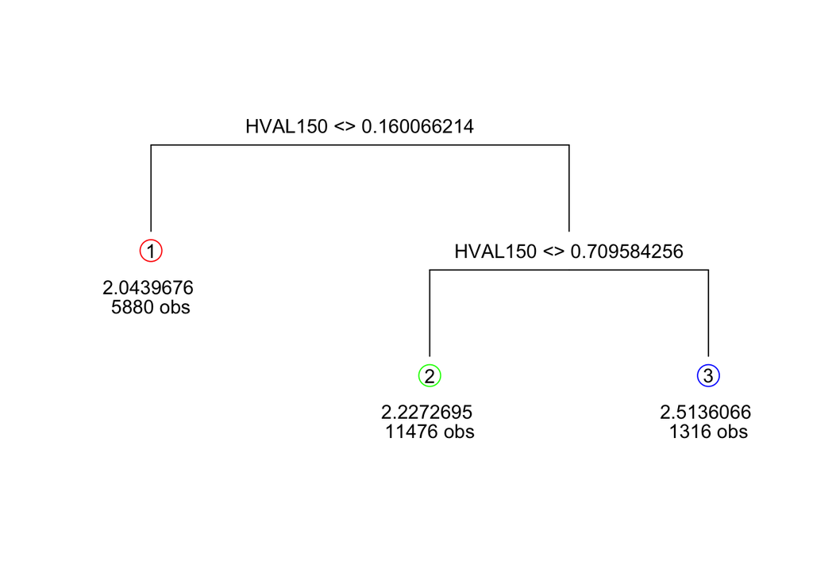

```r
draw.tree(fit)
```

```r
dataToPass$leaf = fit$where
```

```r
chosen_leaves <- c(2,4,5)
stores_in_chosen_leaves <- subset(dataToPass, leaf %in% chosen_leaves)
```

```r
brands <- c("dominicks", "tropicana","minute.maid")
```

```r
leaves <- unique(dataToPass$leaf)
elasticities_list <- list()
elasticity_matrix_2 <- matrix(NA, ncol=3, nrow=3)
colnames(elasticity_matrix_2) <- brands
rownames(elasticity_matrix_2) <- brands
elasticity_matrix_4 <- matrix(NA,ncol=3, nrow=3)
colnames(elasticity_matrix_4) <- brands
rownames(elasticity_matrix_4) <- brands
elasticity_matrix_5 <- matrix(NA, ncol=3,nrow=3)
colnames(elasticity_matrix_5) <- brands
rownames(elasticity_matrix_5) <- brands
```

```r
new_cross_price_data <- merge(cross_price_data_featured[c("logmove", "feat")], cross_price_data, by = 'logmove', all.x = TRUE)
```

```r
oj_leaf_2 = subset(new_cross_price_data, 2 == fit$where)
oj_leaf_2_D = subset(oj_leaf_2, brand =="dominicks")

oj_leaf_2_M = subset(oj_leaf_2, brand == "minute.maid")

oj_leaf_2_T = subset(oj_leaf_2, brand =="tropicana")

#reg_int_2_D <- glm(logmove~log(dominicks)*feat+log(minute.maid)*feat+log(tropicana)*feat, data=oj_leaf_2_D)

#reg_int_2_T <- glm(logmove~log(dominicks)*feat+log(minute.maid)*feat+log(tropicana)*feat, data=oj_leaf_2_T)

oj_leaf_4 = subset(cross_price_data, 4 == fit$where)

oj_leaf_4_D = subset(oj_leaf_4, brand == "dominicks")

#reg_int_4_D <-glm(logmovelog(dominicks)*feat+log(minute,maid)*feat+log(tropicana)*feat, data=oj_leaf_4_D)

oj_leaf_4_M =subset(oj_leaf_4,brand == "minute.maid")

#reg_int_4_M <- glm(logmove~log(dominicks)*feat+log(minute.maid)*feat+log(tropicana)*feat, data=oj_leaf_4_M)

oj_leaf_4_T =subset(oj_leaf_4, brand == "tropicana")

#reg_int_4_T <- glm(loamovelog(dominicks)*feat+log(minute.maid)*feat+log(tropicana)*feat, data=oj_leaf_4_T)

oj_leaf_5 = subset(cross_price_data, 5 == fit$where)

oj_leaf_5_D = subset(oj_leaf_5,brand == "dominicks")

#reg_int_5_D <-glm(logmove~log(dominicks)*feat+log(minute.maid)*feat+log(tropicana)*feat, data=oj_leaf_5_D)

oj_leaf_5_M = subset(oj_leaf_5, brand =="minute .maid")

#reg_int_5_M <- glm(logmove~log(dominicks)*feat+log(minute,maid)*feat+log(tropicana)*feat, data=oj_leaf_5_M)

oj_leaf_5_T = subset(oj_leaf_5,brand == "tropicana")

#reg_int_5_T <- glm(logmovelog(dominicks)*feat+log(minute.maid)*feat+log(tropicana)*feat, data=oj_leaf_5_T)
```

#These reggressions above couldn’t run because I have NA values in my cross_price_data_featured, and I don’t know how to get rid out them.

```r
elasticity_matrix_2[,'dominicks'] <-c(-2.95994722,-0.29529408,0.67151035)
elasticity_matrix_2[,'minute.maid'] <- c(0.4714752,0.3323011,-2.3194298)
elasticity_matrix_2[,'tropicana']<- c(0.1338913,-2.0409940,0.3336818)
elasticity_matrix_4[,'dominicks'] <- c(-2.8342268,-0.2302900,0.8991100)
elasticity_matrix_4[,'minute.maid'] <- c(0.6100305,0.3461332,-2.3402296)
elasticity_matrix_4[,'tropicana']<- c(0.1544927,-2.1930293,0.2963101)
elasticity_matrix_5[,'dominicks'] <-c(-2.5118095,-0.3649431,0.5590767)
elasticity_matrix_5[,'minute.maid'] <- c(0.5856570,0.1803956,-2.4320476)
elasticity_matrix_5[,'tropicana'] <- c(0.2176588,-1.8599167,0.3476085)
elasticities_list[["Leaf_2"]] <- elasticity_matrix_2
elasticities_list[["Leaf_4"]] <- elasticity_matrix_4
elasticities_list[["Leaf_5"]] <- elasticity_matrix_5
elasticities_list
```

```
## $Leaf_2
##              dominicks  tropicana minute.maid
## dominicks   -2.9599472  0.1338913   0.4714752
## tropicana   -0.2952941 -2.0409940   0.3323011
## minute.maid  0.6715104  0.3336818  -2.3194298
##
## $Leaf_4
##             dominicks  tropicana minute.maid
## dominicks   -2.834227  0.1544927   0.6100305
## tropicana   -0.230290 -2.1930293   0.3461332
## minute.maid  0.899110  0.2963101  -2.3402296
##
## $Leaf_5
##              dominicks  tropicana minute.maid
## dominicks   -2.5118095  0.2176588   0.5856570
## tropicana   -0.3649431 -1.8599167   0.1803956
## minute.maid  0.5590767  0.3476085  -2.4320476
```

#An alternative way to do this

```r
new_dataToPass <- merge(df[c("weighted_mean", "logmove","price","brand","feat")], dataToPass, by = 'weighted_mean', all.x = TRUE)
```

```r
leaf1 <- new_dataToPass[new_dataToPass$leaf == 2,]
leaf2 <- new_dataToPass[new_dataToPass$leaf == 4,]
leaf3 <- new_dataToPass[new_dataToPass$leaf == 5,]
```

```r
reg_int_1 <- glm(logmove~log(price)*brand*feat, data=leaf1)
reg_int_2 <- glm(logmove~log(price)*brand*feat, data=leaf2)
reg_int_3 <- glm(logmove~log(price)*brand*feat, data=leaf3)
```

```r
leaf1_D <- leaf1 %>% filter(brand=="dominicks")
```

```r
reg_int_1_D <- glm(logmove~log(price)*feat, data=leaf1_D)
```

```r
cross_price_matrix_lf_1 <- tidy(reg_int_1) %>%
  select(term, estimate) %>%
  filter(str_detect(term, '\\:')) %>%
  mutate(num = str_extract(term, '(?<=brand).*(?=:)'),
         den = str_extract(term, '(?<=:).*(?=$)')) %>%
  select(num, den, estimate) %>%
  arrange(num, den) %>%
  pivot_wider(id_cols = num, names_from = den, values_from = estimate)
kable(cross_price_matrix_lf_1)
```

| num | brandtropicana:feat | feat | brandtropicana |
| --- | --- | --- | --- |
| tropicana | -0.8665597 | 0.3594638 | NA |
| NA | NA | -0.2719729 | -0.2468898 |

1. In the leaf with the highest own-price elasticities, the markups should be lower relative to the other leaves because a high own-price elasticity shows that consumers are very sensative to the price, so prices are increased, consumers will significantly reduce their quantity demanded,so in order to maximize revenue, the store should set a lower markup in these leaves.
3. When cross-price elasticity is high, it means that they are more substitutable, therefore, we may need to decrease markups, or consumers would just go for the substitute product. In contrast, when cross-price cross elasticity is low, consumers might be less responsive to price changes and more loyal to specific brands which allows higher markups.
2. Regarding the timing of sales, if stores have high own-price elasticity and high cross-price elasticity, it might be beneficial to stagger sales across different brands because when one brand is on sale, consumers might switch from other brands due to the price difference.